# Optimal Treatment Analysis

## Outcome Variable

**Outcome Variable:** ever_stunted

## Predictor Variables

**Intervention Variable:** mbmi

**Adjustment Set:**

- arm
- W_mage
- meducyrs
- feducyrs
- single
- brthmon
- delta_W_mage
- delta_meducyrs
- delta_feducyrs
- delta_single
- delta_brthmon

## Stratifying Variables

The analysis was stratified on these variable(s):

- agecat
- studyid
- country

## Data Summary

| agecat | studyid | country | mbmi | ever_stunted | n_cell | n |
| --- | --- | --- | --- | --- | --- | --- |
| 0-24 months | ki0047075b-MAL-ED | BANGLADESH | Normal weight | 0 | 90 | 254 |
| 0-24 months | ki0047075b-MAL-ED | BANGLADESH | Normal weight | 1 | 132 | 254 |
| 0-24 months | ki0047075b-MAL-ED | BANGLADESH | Underweight | 0 | 9 | 254 |
| 0-24 months | ki0047075b-MAL-ED | BANGLADESH | Underweight | 1 | 23 | 254 |
| 0-24 months | ki0047075b-MAL-ED | BRAZIL | Normal weight | 0 | 165 | 221 |
| 0-24 months | ki0047075b-MAL-ED | BRAZIL | Normal weight | 1 | 46 | 221 |
| 0-24 months | ki0047075b-MAL-ED | BRAZIL | Underweight | 0 | 6 | 221 |
| 0-24 months | ki0047075b-MAL-ED | BRAZIL | Underweight | 1 | 4 | 221 |
| 0-24 months | ki0047075b-MAL-ED | INDIA | Normal weight | 0 | 75 | 242 |
| 0-24 months | ki0047075b-MAL-ED | INDIA | Normal weight | 1 | 118 | 242 |
| 0-24 months | ki0047075b-MAL-ED | INDIA | Underweight | 0 | 20 | 242 |
| 0-24 months | ki0047075b-MAL-ED | INDIA | Underweight | 1 | 29 | 242 |
| 0-24 months | ki0047075b-MAL-ED | NEPAL | Normal weight | 0 | 156 | 238 |
| 0-24 months | ki0047075b-MAL-ED | NEPAL | Normal weight | 1 | 82 | 238 |
| 0-24 months | ki0047075b-MAL-ED | NEPAL | Underweight | 0 | 0 | 238 |
| 0-24 months | ki0047075b-MAL-ED | NEPAL | Underweight | 1 | 0 | 238 |
| 0-24 months | ki0047075b-MAL-ED | PERU | Normal weight | 0 | 102 | 290 |
| 0-24 months | ki0047075b-MAL-ED | PERU | Normal weight | 1 | 183 | 290 |
| 0-24 months | ki0047075b-MAL-ED | PERU | Underweight | 0 | 2 | 290 |
| 0-24 months | ki0047075b-MAL-ED | PERU | Underweight | 1 | 3 | 290 |
| 0-24 months | ki0047075b-MAL-ED | SOUTH AFRICA | Normal weight | 0 | 110 | 270 |
| 0-24 months | ki0047075b-MAL-ED | SOUTH AFRICA | Normal weight | 1 | 152 | 270 |
| 0-24 months | ki0047075b-MAL-ED | SOUTH AFRICA | Underweight | 0 | 1 | 270 |
| 0-24 months | ki0047075b-MAL-ED | SOUTH AFRICA | Underweight | 1 | 7 | 270 |
| 0-24 months | ki0047075b-MAL-ED | TANZANIA, UNITED REPUBLIC OF | Normal weight | 0 | 33 | 256 |
| 0-24 months | ki0047075b-MAL-ED | TANZANIA, UNITED REPUBLIC OF | Normal weight | 1 | 209 | 256 |
| 0-24 months | ki0047075b-MAL-ED | TANZANIA, UNITED REPUBLIC OF | Underweight | 0 | 3 | 256 |
| 0-24 months | ki0047075b-MAL-ED | TANZANIA, UNITED REPUBLIC OF | Underweight | 1 | 11 | 256 |
| 0-24 months | ki1000304b-SAS-CompFeed | INDIA | Normal weight | 0 | 360 | 1406 |
| 0-24 months | ki1000304b-SAS-CompFeed | INDIA | Normal weight | 1 | 691 | 1406 |

[output cut: 158 more lines]

The following strata were considered:

- agecat: 0-24 months, studyid: ki0047075b-MAL-ED, country: BANGLADESH
- agecat: 0-24 months, studyid: ki0047075b-MAL-ED, country: BRAZIL
- agecat: 0-24 months, studyid: ki0047075b-MAL-ED, country: INDIA
- agecat: 0-24 months, studyid: ki0047075b-MAL-ED, country: NEPAL
- agecat: 0-24 months, studyid: ki0047075b-MAL-ED, country: PERU
- agecat: 0-24 months, studyid: ki0047075b-MAL-ED, country: SOUTH AFRICA
- agecat: 0-24 months, studyid: ki0047075b-MAL-ED, country: TANZANIA, UNITED REPUBLIC OF
- agecat: 0-24 months, studyid: ki1000304b-SAS-CompFeed, country: INDIA
- agecat: 0-24 months, studyid: ki1017093-NIH-Birth, country: BANGLADESH
- agecat: 0-24 months, studyid: ki1017093b-PROVIDE, country: BANGLADESH
- agecat: 0-24 months, studyid: ki1017093c-NIH-Crypto, country: BANGLADESH
- agecat: 0-24 months, studyid: ki1066203-TanzaniaChild2, country: TANZANIA, UNITED REPUBLIC OF
- agecat: 0-24 months, studyid: ki1112895-iLiNS-Zinc, country: BURKINA FASO
- agecat: 0-24 months, studyid: ki1119695-PROBIT, country: BELARUS
- agecat: 0-24 months, studyid: ki1126311-ZVITAMBO, country: ZIMBABWE
- agecat: 0-24 months, studyid: ki1148112-LCNI-5, country: MALAWI
- agecat: 0-6 months, studyid: ki0047075b-MAL-ED, country: BANGLADESH
- agecat: 0-6 months, studyid: ki0047075b-MAL-ED, country: BRAZIL
- agecat: 0-6 months, studyid: ki0047075b-MAL-ED, country: INDIA
- agecat: 0-6 months, studyid: ki0047075b-MAL-ED, country: NEPAL
- agecat: 0-6 months, studyid: ki0047075b-MAL-ED, country: PERU
- agecat: 0-6 months, studyid: ki0047075b-MAL-ED, country: SOUTH AFRICA
- agecat: 0-6 months, studyid: ki0047075b-MAL-ED, country: TANZANIA, UNITED REPUBLIC OF
- agecat: 0-6 months, studyid: ki1000304b-SAS-CompFeed, country: INDIA
- agecat: 0-6 months, studyid: ki1017093-NIH-Birth, country: BANGLADESH
- agecat: 0-6 months, studyid: ki1017093b-PROVIDE, country: BANGLADESH
- agecat: 0-6 months, studyid: ki1017093c-NIH-Crypto, country: BANGLADESH
- agecat: 0-6 months, studyid: ki1066203-TanzaniaChild2, country: TANZANIA, UNITED REPUBLIC OF
- agecat: 0-6 months, studyid: ki1119695-PROBIT, country: BELARUS
- agecat: 0-6 months, studyid: ki1126311-ZVITAMBO, country: ZIMBABWE
- agecat: 0-6 months, studyid: ki1148112-LCNI-5, country: MALAWI
- agecat: 6-24 months, studyid: ki0047075b-MAL-ED, country: BANGLADESH
- agecat: 6-24 months, studyid: ki0047075b-MAL-ED, country: BRAZIL
- agecat: 6-24 months, studyid: ki0047075b-MAL-ED, country: INDIA
- agecat: 6-24 months, studyid: ki0047075b-MAL-ED, country: NEPAL
- agecat: 6-24 months, studyid: ki0047075b-MAL-ED, country: PERU
- agecat: 6-24 months, studyid: ki0047075b-MAL-ED, country: SOUTH AFRICA
- agecat: 6-24 months, studyid: ki0047075b-MAL-ED, country: TANZANIA, UNITED REPUBLIC OF
- agecat: 6-24 months, studyid: ki1000304b-SAS-CompFeed, country: INDIA
- agecat: 6-24 months, studyid: ki1017093-NIH-Birth, country: BANGLADESH
- agecat: 6-24 months, studyid: ki1017093b-PROVIDE, country: BANGLADESH
- agecat: 6-24 months, studyid: ki1017093c-NIH-Crypto, country: BANGLADESH
- agecat: 6-24 months, studyid: ki1066203-TanzaniaChild2, country: TANZANIA, UNITED REPUBLIC OF
- agecat: 6-24 months, studyid: ki1112895-iLiNS-Zinc, country: BURKINA FASO
- agecat: 6-24 months, studyid: ki1119695-PROBIT, country: BELARUS
- agecat: 6-24 months, studyid: ki1126311-ZVITAMBO, country: ZIMBABWE
- agecat: 6-24 months, studyid: ki1148112-LCNI-5, country: MALAWI

### Dropped Strata

Some strata were dropped due to rare outcomes:

- agecat: 0-24 months, studyid: ki0047075b-MAL-ED, country: BRAZIL
- agecat: 0-24 months, studyid: ki0047075b-MAL-ED, country: NEPAL
- agecat: 0-24 months, studyid: ki0047075b-MAL-ED, country: PERU
- agecat: 0-24 months, studyid: ki0047075b-MAL-ED, country: SOUTH AFRICA
- agecat: 0-24 months, studyid: ki0047075b-MAL-ED, country: TANZANIA, UNITED REPUBLIC OF
- agecat: 0-6 months, studyid: ki0047075b-MAL-ED, country: BRAZIL
- agecat: 0-6 months, studyid: ki0047075b-MAL-ED, country: NEPAL
- agecat: 0-6 months, studyid: ki0047075b-MAL-ED, country: PERU
- agecat: 0-6 months, studyid: ki0047075b-MAL-ED, country: SOUTH AFRICA
- agecat: 6-24 months, studyid: ki0047075b-MAL-ED, country: BRAZIL
- agecat: 6-24 months, studyid: ki0047075b-MAL-ED, country: NEPAL
- agecat: 6-24 months, studyid: ki0047075b-MAL-ED, country: PERU
- agecat: 6-24 months, studyid: ki0047075b-MAL-ED, country: SOUTH AFRICA
- agecat: 6-24 months, studyid: ki0047075b-MAL-ED, country: TANZANIA, UNITED REPUBLIC OF

## Methods Detail

We’re interested in the causal parameters $E[Y_a]$ for all values of $a \in \mathcal{A}$. These parameters represent the mean outcome if, possibly contrary to fact, we intervened to set all units to have $A=a$. Under the randomization and positivity assumptions, these are identified by the statistical parameters $\psi_a=E_W[E_{Y|A,W}(Y|A=a,W)]$. In addition, we’re interested in the mean of $Y$, $E[Y]$ under no intervention (the observed mean). We will estimate these parameters by using SuperLearner to fit the relevant likelihood factors – $E_{Y|A,W}(Y|A=a,W)$ and $p(A=a|W)$, and then updating our likelihood fit using a joint TMLE.

For unadjusted analyses ($W=\{\}$), initial likelihoods were estimated using Lrnr_glm to estimate the simple $E(Y|A)$ and Lrnr_mean to estimate $p(A)$. For adjusted analyses, a small library containing Lrnr_glmnet, Lrnr_xgboost, and Lrnr_mean was used.

Having estimated these parameters, we will then use the delta method to estimate relative risks and attributable risks relative to a prespecified baseline level of $A$.

# Results Detail

## Results Plots

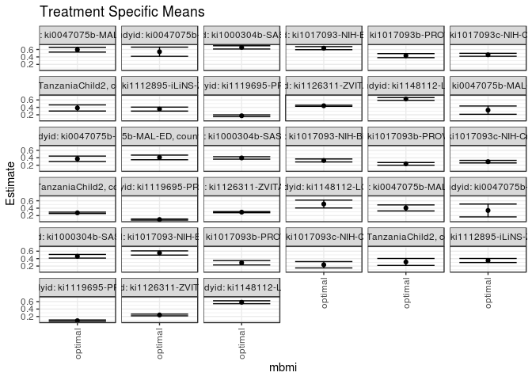

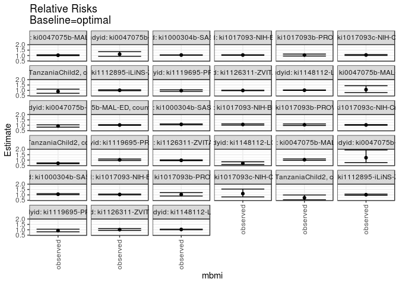

## Results Table

### Parameter: TSM

| agecat | studyid | country | intervention_level | baseline_level | estimate | ci_lower | ci_upper |
| --- | --- | --- | --- | --- | --- | --- | --- |
| 0-24 months | ki0047075b-MAL-ED | BANGLADESH | optimal | NA | 0.5948664 | 0.5300876 | 0.6596452 |
| 0-24 months | ki0047075b-MAL-ED | INDIA | optimal | NA | 0.5399987 | 0.4161684 | 0.6638290 |
| 0-24 months | ki1000304b-SAS-CompFeed | INDIA | optimal | NA | 0.6569104 | 0.6129884 | 0.7008323 |
| 0-24 months | ki1017093-NIH-Birth | BANGLADESH | optimal | NA | 0.6359501 | 0.5946558 | 0.6772445 |
| 0-24 months | ki1017093b-PROVIDE | BANGLADESH | optimal | NA | 0.4346596 | 0.3802481 | 0.4890711 |
| 0-24 months | ki1017093c-NIH-Crypto | BANGLADESH | optimal | NA | 0.4566971 | 0.4168488 | 0.4965454 |
| 0-24 months | ki1066203-TanzaniaChild2 | TANZANIA, UNITED REPUBLIC OF | optimal | NA | 0.3834930 | 0.3006749 | 0.4663111 |
| 0-24 months | ki1112895-iLiNS-Zinc | BURKINA FASO | optimal | NA | 0.3529415 | 0.2992945 | 0.4065884 |
| 0-24 months | ki1119695-PROBIT | BELARUS | optimal | NA | 0.1733465 | 0.1494903 | 0.1972027 |
| 0-24 months | ki1126311-ZVITAMBO | ZIMBABWE | optimal | NA | 0.4426570 | 0.4281224 | 0.4571915 |
| 0-24 months | ki1148112-LCNI-5 | MALAWI | optimal | NA | 0.6261012 | 0.5899792 | 0.6622232 |
| 0-6 months | ki0047075b-MAL-ED | BANGLADESH | optimal | NA | 0.3246673 | 0.2129714 | 0.4363631 |
| 0-6 months | ki0047075b-MAL-ED | INDIA | optimal | NA | 0.3719065 | 0.2986381 | 0.4451749 |
| 0-6 months | ki0047075b-MAL-ED | TANZANIA, UNITED REPUBLIC OF | optimal | NA | 0.4097103 | 0.3475933 | 0.4718273 |
| 0-6 months | ki1000304b-SAS-CompFeed | INDIA | optimal | NA | 0.3957827 | 0.3631045 | 0.4284609 |
| 0-6 months | ki1017093-NIH-Birth | BANGLADESH | optimal | NA | 0.3277986 | 0.2876074 | 0.3679899 |
| 0-6 months | ki1017093b-PROVIDE | BANGLADESH | optimal | NA | 0.2362649 | 0.2000922 | 0.2724376 |
| 0-6 months | ki1017093c-NIH-Crypto | BANGLADESH | optimal | NA | 0.2956264 | 0.2613360 | 0.3299168 |
| 0-6 months | ki1066203-TanzaniaChild2 | TANZANIA, UNITED REPUBLIC OF | optimal | NA | 0.2753808 | 0.2570781 | 0.2936834 |
| 0-6 months | ki1119695-PROBIT | BELARUS | optimal | NA | 0.0947898 | 0.0802239 | 0.1093558 |
| 0-6 months | ki1126311-ZVITAMBO | ZIMBABWE | optimal | NA | 0.2930531 | 0.2787917 | 0.3073144 |
| 0-6 months | ki1148112-LCNI-5 | MALAWI | optimal | NA | 0.5122927 | 0.4065851 | 0.6180002 |
| 6-24 months | ki0047075b-MAL-ED | BANGLADESH | optimal | NA | 0.4071806 | 0.3259633 | 0.4883979 |
| 6-24 months | ki0047075b-MAL-ED | INDIA | optimal | NA | 0.3388850 | 0.1659406 | 0.5118293 |
| 6-24 months | ki1000304b-SAS-CompFeed | INDIA | optimal | NA | 0.4628906 | 0.4135174 | 0.5122639 |
| 6-24 months | ki1017093-NIH-Birth | BANGLADESH | optimal | NA | 0.5518463 | 0.4950852 | 0.6086074 |
| 6-24 months | ki1017093b-PROVIDE | BANGLADESH | optimal | NA | 0.2880050 | 0.2294048 | 0.3466052 |
| 6-24 months | ki1017093c-NIH-Crypto | BANGLADESH | optimal | NA | 0.2346050 | 0.1496610 | 0.3195491 |
| 6-24 months | ki1066203-TanzaniaChild2 | TANZANIA, UNITED REPUBLIC OF | optimal | NA | 0.3102053 | 0.2165356 | 0.4038749 |
| 6-24 months | ki1112895-iLiNS-Zinc | BURKINA FASO | optimal | NA | 0.3489716 | 0.2944530 | 0.4034901 |
| 6-24 months | ki1119695-PROBIT | BELARUS | optimal | NA | 0.0867251 | 0.0675905 | 0.1058598 |
| 6-24 months | ki1126311-ZVITAMBO | ZIMBABWE | optimal | NA | 0.2405470 | 0.2173104 | 0.2637836 |
| 6-24 months | ki1148112-LCNI-5 | MALAWI | optimal | NA | 0.5828536 | 0.5433785 | 0.6223287 |

### Parameter: E(Y)

| agecat | studyid | country | intervention_level | baseline_level | estimate | ci_lower | ci_upper |
| --- | --- | --- | --- | --- | --- | --- | --- |
| 0-24 months | ki0047075b-MAL-ED | BANGLADESH | observed | NA | 0.6102362 | 0.5501413 | 0.6703311 |
| 0-24 months | ki0047075b-MAL-ED | INDIA | observed | NA | 0.6074380 | 0.5457864 | 0.6690897 |
| 0-24 months | ki1000304b-SAS-CompFeed | INDIA | observed | NA | 0.6863442 | 0.6430946 | 0.7295939 |
| 0-24 months | ki1017093-NIH-Birth | BANGLADESH | observed | NA | 0.6645469 | 0.6276196 | 0.7014742 |
| 0-24 months | ki1017093b-PROVIDE | BANGLADESH | observed | NA | 0.4514200 | 0.4136828 | 0.4891573 |
| 0-24 months | ki1017093c-NIH-Crypto | BANGLADESH | observed | NA | 0.4794702 | 0.4438115 | 0.5151289 |
| 0-24 months | ki1066203-TanzaniaChild2 | TANZANIA, UNITED REPUBLIC OF | observed | NA | 0.3454158 | 0.3261661 | 0.3646654 |
| 0-24 months | ki1112895-iLiNS-Zinc | BURKINA FASO | observed | NA | 0.3559962 | 0.3060347 | 0.4059578 |
| 0-24 months | ki1119695-PROBIT | BELARUS | observed | NA | 0.1692890 | 0.1503168 | 0.1882613 |
| 0-24 months | ki1126311-ZVITAMBO | ZIMBABWE | observed | NA | 0.4391486 | 0.4293319 | 0.4489653 |
| 0-24 months | ki1148112-LCNI-5 | MALAWI | observed | NA | 0.6356033 | 0.6029802 | 0.6682264 |
| 0-6 months | ki0047075b-MAL-ED | BANGLADESH | observed | NA | 0.3464567 | 0.2878227 | 0.4050907 |
| 0-6 months | ki0047075b-MAL-ED | INDIA | observed | NA | 0.3429752 | 0.2830428 | 0.4029076 |
| 0-6 months | ki0047075b-MAL-ED | TANZANIA, UNITED REPUBLIC OF | observed | NA | 0.4179688 | 0.3574314 | 0.4785061 |
| 0-6 months | ki1000304b-SAS-CompFeed | INDIA | observed | NA | 0.4269423 | 0.3929328 | 0.4609518 |
| 0-6 months | ki1017093-NIH-Birth | BANGLADESH | observed | NA | 0.3497615 | 0.3124631 | 0.3870600 |
| 0-6 months | ki1017093b-PROVIDE | BANGLADESH | observed | NA | 0.2466368 | 0.2139486 | 0.2793250 |
| 0-6 months | ki1017093c-NIH-Crypto | BANGLADESH | observed | NA | 0.3033113 | 0.2704998 | 0.3361228 |
| 0-6 months | ki1066203-TanzaniaChild2 | TANZANIA, UNITED REPUBLIC OF | observed | NA | 0.1927505 | 0.1767818 | 0.2087193 |
| 0-6 months | ki1119695-PROBIT | BELARUS | observed | NA | 0.0970280 | 0.0839943 | 0.1100616 |
| 0-6 months | ki1126311-ZVITAMBO | ZIMBABWE | observed | NA | 0.2863261 | 0.2773790 | 0.2952732 |
| 0-6 months | ki1148112-LCNI-5 | MALAWI | observed | NA | 0.3579336 | 0.3007518 | 0.4151153 |
| 6-24 months | ki0047075b-MAL-ED | BANGLADESH | observed | NA | 0.4213836 | 0.3443902 | 0.4983771 |
| 6-24 months | ki0047075b-MAL-ED | INDIA | observed | NA | 0.4129032 | 0.3351414 | 0.4906651 |
| 6-24 months | ki1000304b-SAS-CompFeed | INDIA | observed | NA | 0.4932615 | 0.4489809 | 0.5375420 |
| 6-24 months | ki1017093-NIH-Birth | BANGLADESH | observed | NA | 0.5739130 | 0.5216565 | 0.6261696 |
| 6-24 months | ki1017093b-PROVIDE | BANGLADESH | observed | NA | 0.2997812 | 0.2577294 | 0.3418330 |
| 6-24 months | ki1017093c-NIH-Crypto | BANGLADESH | observed | NA | 0.2628458 | 0.2244546 | 0.3012371 |
| 6-24 months | ki1066203-TanzaniaChild2 | TANZANIA, UNITED REPUBLIC OF | observed | NA | 0.2280255 | 0.2072654 | 0.2487856 |
| 6-24 months | ki1112895-iLiNS-Zinc | BURKINA FASO | observed | NA | 0.3559962 | 0.3060347 | 0.4059578 |
| 6-24 months | ki1119695-PROBIT | BELARUS | observed | NA | 0.0800775 | 0.0658478 | 0.0943072 |
| 6-24 months | ki1126311-ZVITAMBO | ZIMBABWE | observed | NA | 0.2438392 | 0.2331223 | 0.2545561 |
| 6-24 months | ki1148112-LCNI-5 | MALAWI | observed | NA | 0.5983494 | 0.5626894 | 0.6340094 |

### Parameter: RR

| agecat | studyid | country | intervention_level | baseline_level | estimate | ci_lower | ci_upper |
| --- | --- | --- | --- | --- | --- | --- | --- |
| 0-24 months | ki0047075b-MAL-ED | BANGLADESH | observed | optimal | 1.0258375 | 0.9886564 | 1.0644168 |
| 0-24 months | ki0047075b-MAL-ED | INDIA | observed | optimal | 1.1248879 | 0.9277468 | 1.3639204 |
| 0-24 months | ki1000304b-SAS-CompFeed | INDIA | observed | optimal | 1.0448065 | 1.0279941 | 1.0618939 |
| 0-24 months | ki1017093-NIH-Birth | BANGLADESH | observed | optimal | 1.0449670 | 1.0196181 | 1.0709461 |
| 0-24 months | ki1017093b-PROVIDE | BANGLADESH | observed | optimal | 1.0385599 | 0.9510094 | 1.1341705 |
| 0-24 months | ki1017093c-NIH-Crypto | BANGLADESH | observed | optimal | 1.0498648 | 1.0049306 | 1.0968082 |
| 0-24 months | ki1066203-TanzaniaChild2 | TANZANIA, UNITED REPUBLIC OF | observed | optimal | 0.9007095 | 0.7291348 | 1.1126579 |
| 0-24 months | ki1112895-iLiNS-Zinc | BURKINA FASO | observed | optimal | 1.0086551 | 0.9655208 | 1.0537164 |
| 0-24 months | ki1119695-PROBIT | BELARUS | observed | optimal | 0.9765936 | 0.9056884 | 1.0530498 |
| 0-24 months | ki1126311-ZVITAMBO | ZIMBABWE | observed | optimal | 0.9920743 | 0.9683352 | 1.0163953 |
| 0-24 months | ki1148112-LCNI-5 | MALAWI | observed | optimal | 1.0151767 | 0.9916320 | 1.0392804 |
| 0-6 months | ki0047075b-MAL-ED | BANGLADESH | observed | optimal | 1.0671131 | 0.7964039 | 1.4298403 |
| 0-6 months | ki0047075b-MAL-ED | INDIA | observed | optimal | 0.9222082 | 0.8203582 | 1.0367031 |
| 0-6 months | ki0047075b-MAL-ED | TANZANIA, UNITED REPUBLIC OF | observed | optimal | 1.0201569 | 0.9828264 | 1.0589053 |
| 0-6 months | ki1000304b-SAS-CompFeed | INDIA | observed | optimal | 1.0787289 | 1.0381513 | 1.1208926 |
| 0-6 months | ki1017093-NIH-Birth | BANGLADESH | observed | optimal | 1.0670012 | 1.0100414 | 1.1271732 |
| 0-6 months | ki1017093b-PROVIDE | BANGLADESH | observed | optimal | 1.0438993 | 0.9711997 | 1.1220409 |
| 0-6 months | ki1017093c-NIH-Crypto | BANGLADESH | observed | optimal | 1.0259952 | 0.9875904 | 1.0658936 |
| 0-6 months | ki1066203-TanzaniaChild2 | TANZANIA, UNITED REPUBLIC OF | observed | optimal | 0.6999419 | 0.6653935 | 0.7362841 |
| 0-6 months | ki1119695-PROBIT | BELARUS | observed | optimal | 1.0236118 | 0.9541983 | 1.0980747 |
| 0-6 months | ki1126311-ZVITAMBO | ZIMBABWE | observed | optimal | 0.9770452 | 0.9410359 | 1.0144325 |
| 0-6 months | ki1148112-LCNI-5 | MALAWI | observed | optimal | 0.6986897 | 0.5807173 | 0.8406280 |
| 6-24 months | ki0047075b-MAL-ED | BANGLADESH | observed | optimal | 1.0348815 | 0.9665735 | 1.1080168 |
| 6-24 months | ki0047075b-MAL-ED | INDIA | observed | optimal | 1.2184171 | 0.7671131 | 1.9352300 |
| 6-24 months | ki1000304b-SAS-CompFeed | INDIA | observed | optimal | 1.0656113 | 1.0204095 | 1.1128154 |
| 6-24 months | ki1017093-NIH-Birth | BANGLADESH | observed | optimal | 1.0399870 | 1.0015616 | 1.0798867 |
| 6-24 months | ki1017093b-PROVIDE | BANGLADESH | observed | optimal | 1.0408887 | 0.8946546 | 1.2110252 |
| 6-24 months | ki1017093c-NIH-Crypto | BANGLADESH | observed | optimal | 1.1203759 | 0.8136241 | 1.5427791 |
| 6-24 months | ki1066203-TanzaniaChild2 | TANZANIA, UNITED REPUBLIC OF | observed | optimal | 0.7350792 | 0.5447850 | 0.9918436 |
| 6-24 months | ki1112895-iLiNS-Zinc | BURKINA FASO | observed | optimal | 1.0201295 | 0.9667714 | 1.0764326 |
| 6-24 months | ki1119695-PROBIT | BELARUS | observed | optimal | 0.9233482 | 0.8081978 | 1.0549050 |
| 6-24 months | ki1126311-ZVITAMBO | ZIMBABWE | observed | optimal | 1.0136862 | 0.9304781 | 1.1043351 |
| 6-24 months | ki1148112-LCNI-5 | MALAWI | observed | optimal | 1.0265860 | 0.9989841 | 1.0549506 |

### Parameter: PAR

| agecat | studyid | country | intervention_level | baseline_level | estimate | ci_lower | ci_upper |
| --- | --- | --- | --- | --- | --- | --- | --- |
| 0-24 months | ki0047075b-MAL-ED | BANGLADESH | optimal | NA | 0.0153699 | -0.0064771 | 0.0372168 |
| 0-24 months | ki0047075b-MAL-ED | INDIA | optimal | NA | 0.0674393 | -0.0359276 | 0.1708062 |
| 0-24 months | ki1000304b-SAS-CompFeed | INDIA | optimal | NA | 0.0294339 | 0.0188305 | 0.0400372 |
| 0-24 months | ki1017093-NIH-Birth | BANGLADESH | optimal | NA | 0.0285968 | 0.0132064 | 0.0439871 |
| 0-24 months | ki1017093b-PROVIDE | BANGLADESH | optimal | NA | 0.0167604 | -0.0214559 | 0.0549768 |
| 0-24 months | ki1017093c-NIH-Crypto | BANGLADESH | optimal | NA | 0.0227731 | 0.0027680 | 0.0427783 |
| 0-24 months | ki1066203-TanzaniaChild2 | TANZANIA, UNITED REPUBLIC OF | optimal | NA | -0.0380772 | -0.1190448 | 0.0428904 |
| 0-24 months | ki1112895-iLiNS-Zinc | BURKINA FASO | optimal | NA | 0.0030547 | -0.0123243 | 0.0184338 |
| 0-24 months | ki1119695-PROBIT | BELARUS | optimal | NA | -0.0040574 | -0.0171501 | 0.0090353 |
| 0-24 months | ki1126311-ZVITAMBO | ZIMBABWE | optimal | NA | -0.0035084 | -0.0142291 | 0.0072123 |
| 0-24 months | ki1148112-LCNI-5 | MALAWI | optimal | NA | 0.0095021 | -0.0051689 | 0.0241732 |
| 0-6 months | ki0047075b-MAL-ED | BANGLADESH | optimal | NA | 0.0217894 | -0.0731291 | 0.1167079 |
| 0-6 months | ki0047075b-MAL-ED | INDIA | optimal | NA | -0.0289313 | -0.0720776 | 0.0142150 |
| 0-6 months | ki0047075b-MAL-ED | TANZANIA, UNITED REPUBLIC OF | optimal | NA | 0.0082585 | -0.0069935 | 0.0235105 |
| 0-6 months | ki1000304b-SAS-CompFeed | INDIA | optimal | NA | 0.0311595 | 0.0153875 | 0.0469316 |
| 0-6 months | ki1017093-NIH-Birth | BANGLADESH | optimal | NA | 0.0219629 | 0.0039575 | 0.0399683 |
| 0-6 months | ki1017093b-PROVIDE | BANGLADESH | optimal | NA | 0.0103719 | -0.0066909 | 0.0274346 |
| 0-6 months | ki1017093c-NIH-Crypto | BANGLADESH | optimal | NA | 0.0076849 | -0.0035942 | 0.0189639 |
| 0-6 months | ki1066203-TanzaniaChild2 | TANZANIA, UNITED REPUBLIC OF | optimal | NA | -0.0826302 | -0.0939087 | -0.0713518 |
| 0-6 months | ki1119695-PROBIT | BELARUS | optimal | NA | 0.0022382 | -0.0044147 | 0.0088910 |
| 0-6 months | ki1126311-ZVITAMBO | ZIMBABWE | optimal | NA | -0.0067270 | -0.0177320 | 0.0042780 |
| 0-6 months | ki1148112-LCNI-5 | MALAWI | optimal | NA | -0.1543591 | -0.2450708 | -0.0636474 |
| 6-24 months | ki0047075b-MAL-ED | BANGLADESH | optimal | NA | 0.0142031 | -0.0135416 | 0.0419477 |
| 6-24 months | ki0047075b-MAL-ED | INDIA | optimal | NA | 0.0740183 | -0.0825220 | 0.2305585 |
| 6-24 months | ki1000304b-SAS-CompFeed | INDIA | optimal | NA | 0.0303708 | 0.0106287 | 0.0501130 |
| 6-24 months | ki1017093-NIH-Birth | BANGLADESH | optimal | NA | 0.0220667 | 0.0014497 | 0.0426837 |
| 6-24 months | ki1017093b-PROVIDE | BANGLADESH | optimal | NA | 0.0117761 | -0.0319034 | 0.0554557 |
| 6-24 months | ki1017093c-NIH-Crypto | BANGLADESH | optimal | NA | 0.0282408 | -0.0466001 | 0.1030817 |
| 6-24 months | ki1066203-TanzaniaChild2 | TANZANIA, UNITED REPUBLIC OF | optimal | NA | -0.0821798 | -0.1744712 | 0.0101116 |
| 6-24 months | ki1112895-iLiNS-Zinc | BURKINA FASO | optimal | NA | 0.0070246 | -0.0116295 | 0.0256788 |
| 6-24 months | ki1119695-PROBIT | BELARUS | optimal | NA | -0.0066476 | -0.0182438 | 0.0049485 |
| 6-24 months | ki1126311-ZVITAMBO | ZIMBABWE | optimal | NA | 0.0032922 | -0.0173100 | 0.0238943 |
| 6-24 months | ki1148112-LCNI-5 | MALAWI | optimal | NA | 0.0154958 | -0.0003336 | 0.0313252 |

### Parameter: PAF

| agecat | studyid | country | intervention_level | baseline_level | estimate | ci_lower | ci_upper |
| --- | --- | --- | --- | --- | --- | --- | --- |
| 0-24 months | ki0047075b-MAL-ED | BANGLADESH | optimal | NA | 0.0251867 | -0.0114737 | 0.0605184 |
| 0-24 months | ki0047075b-MAL-ED | INDIA | optimal | NA | 0.1110225 | -0.0778803 | 0.2668194 |
| 0-24 months | ki1000304b-SAS-CompFeed | INDIA | optimal | NA | 0.0428850 | 0.0272318 | 0.0582863 |
| 0-24 months | ki1017093-NIH-Birth | BANGLADESH | optimal | NA | 0.0430320 | 0.0192406 | 0.0662462 |
| 0-24 months | ki1017093b-PROVIDE | BANGLADESH | optimal | NA | 0.0371283 | -0.0515143 | 0.1182983 |
| 0-24 months | ki1017093c-NIH-Crypto | BANGLADESH | optimal | NA | 0.0474964 | 0.0049064 | 0.0882636 |
| 0-24 months | ki1066203-TanzaniaChild2 | TANZANIA, UNITED REPUBLIC OF | optimal | NA | -0.1102359 | -0.3714885 | 0.1012511 |
| 0-24 months | ki1112895-iLiNS-Zinc | BURKINA FASO | optimal | NA | 0.0085808 | -0.0357105 | 0.0509780 |
| 0-24 months | ki1119695-PROBIT | BELARUS | optimal | NA | -0.0239674 | -0.1041325 | 0.0503773 |
| 0-24 months | ki1126311-ZVITAMBO | ZIMBABWE | optimal | NA | -0.0079890 | -0.0327002 | 0.0161308 |
| 0-24 months | ki1148112-LCNI-5 | MALAWI | optimal | NA | 0.0149498 | -0.0084386 | 0.0377958 |
| 0-6 months | ki0047075b-MAL-ED | BANGLADESH | optimal | NA | 0.0628922 | -0.2556444 | 0.3006212 |
| 0-6 months | ki0047075b-MAL-ED | INDIA | optimal | NA | -0.0843539 | -0.2189796 | 0.0354037 |
| 0-6 months | ki0047075b-MAL-ED | TANZANIA, UNITED REPUBLIC OF | optimal | NA | 0.0197586 | -0.0174737 | 0.0556285 |
| 0-6 months | ki1000304b-SAS-CompFeed | INDIA | optimal | NA | 0.0729830 | 0.0367492 | 0.1078539 |
| 0-6 months | ki1017093-NIH-Birth | BANGLADESH | optimal | NA | 0.0627939 | 0.0099416 | 0.1128249 |
| 0-6 months | ki1017093b-PROVIDE | BANGLADESH | optimal | NA | 0.0420532 | -0.0296544 | 0.1087669 |
| 0-6 months | ki1017093c-NIH-Crypto | BANGLADESH | optimal | NA | 0.0253366 | -0.0125656 | 0.0618200 |
| 0-6 months | ki1066203-TanzaniaChild2 | TANZANIA, UNITED REPUBLIC OF | optimal | NA | -0.4286900 | -0.5028701 | -0.3581714 |
| 0-6 months | ki1119695-PROBIT | BELARUS | optimal | NA | 0.0230671 | -0.0480001 | 0.0893151 |
| 0-6 months | ki1126311-ZVITAMBO | ZIMBABWE | optimal | NA | -0.0234941 | -0.0626587 | 0.0142271 |
| 0-6 months | ki1148112-LCNI-5 | MALAWI | optimal | NA | -0.4312506 | -0.7220081 | -0.1895869 |
| 6-24 months | ki0047075b-MAL-ED | BANGLADESH | optimal | NA | 0.0337058 | -0.0345825 | 0.0974866 |
| 6-24 months | ki0047075b-MAL-ED | INDIA | optimal | NA | 0.1792630 | -0.3035888 | 0.4832656 |
| 6-24 months | ki1000304b-SAS-CompFeed | INDIA | optimal | NA | 0.0615715 | 0.0200013 | 0.1013783 |
| 6-24 months | ki1017093-NIH-Birth | BANGLADESH | optimal | NA | 0.0384496 | 0.0015592 | 0.0739769 |
| 6-24 months | ki1017093b-PROVIDE | BANGLADESH | optimal | NA | 0.0392825 | -0.1177498 | 0.1742534 |
| 6-24 months | ki1017093c-NIH-Crypto | BANGLADESH | optimal | NA | 0.1074424 | -0.2290688 | 0.3518190 |
| 6-24 months | ki1066203-TanzaniaChild2 | TANZANIA, UNITED REPUBLIC OF | optimal | NA | -0.3603975 | -0.8355865 | -0.0082235 |
| 6-24 months | ki1112895-iLiNS-Zinc | BURKINA FASO | optimal | NA | 0.0197323 | -0.0343707 | 0.0710055 |
| 6-24 months | ki1119695-PROBIT | BELARUS | optimal | NA | -0.0830151 | -0.2373209 | 0.0520473 |
| 6-24 months | ki1126311-ZVITAMBO | ZIMBABWE | optimal | NA | 0.0135014 | -0.0747163 | 0.0944777 |
| 6-24 months | ki1148112-LCNI-5 | MALAWI | optimal | NA | 0.0258975 | -0.0010169 | 0.0520883 |